# FRED inflation

## Necessary packages

```r
library(MASS) # for the stepAIC() function
library(quantmod) # Extracting data
library(tsibble)
library(tidyverse)
library(ggplot2)
library(scales)
library(aTSA)
library(dynlm)
library(car)
library(sandwich)
library(modelsummary)
library(leaps) # for the leaps() function
```

## Extracting the data from FRED and indexing:

This code chunk below uses the quantmod package to get FRED data via its API.

```r
cpi=getSymbols('CPIAUCSL',src='FRED',auto.assign=F)['1992-01-01/']
cpi=cpi/cpi[[1]]*100
ppi=getSymbols('PITGCG01USM661N',src='FRED',auto.assign=F)['1992-01-01/']
ppi=ppi/ppi[[1]]*100
energy=getSymbols('PNRGINDEXM',src='FRED',auto.assign=F)['1992-01-01/']
energy=energy/energy[[1]]*100
food=getSymbols('PFOODINDEXM',src='FRED',auto.assign=F)['1992-01-01/']
food=food/food[[1]]*100
used_cars=getSymbols('CUSR0000SETA02',src='FRED',auto.assign=F)['1992-01-01/']
used_cars=used_cars/used_cars[[1]]*100
housing=getSymbols('CPIHOSNS',src='FRED',auto.assign=F)['1992-01-01/']
Unemployment=getSymbols('UNRATE',src='FRED',auto.assign=F)['1992-01-01/']/100
Electricity_avg=getSymbols('APU000072610',src='FRED',auto.assign=F)['1992-01-01/']
Electricity_avg=Electricity_avg/Electricity_avg[[1]]*100
```

## EDA:

For all indices

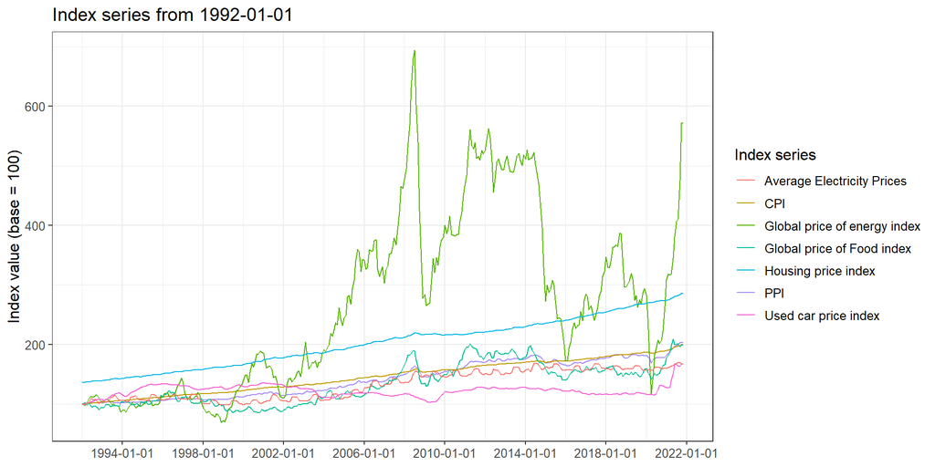

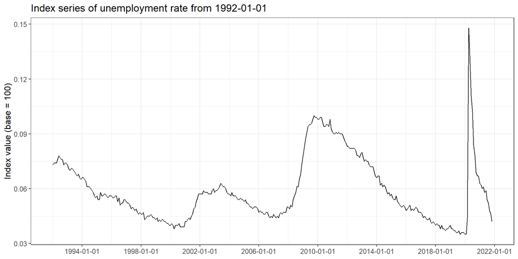

Big Spike for Unemployment during covid that might have a significant impact on model. This informs our rationale to test COVID as a factor of inflation.

All of our series are non-stationary in their current form. As such, we choose to: 1. Take the log of all indices (so this excludes unemployment rate) 2. Take the first difference of the logged series, and the first difference of unemployment rate.

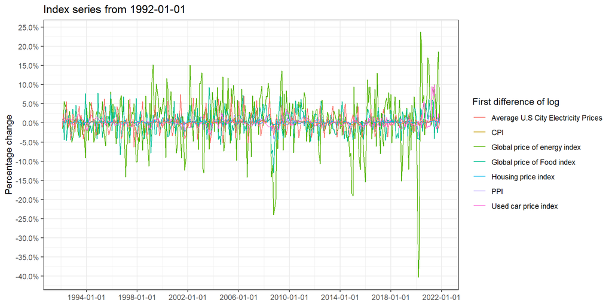

```r
ggplot(data=NULL,aes(x=final_ts_df$Date[-1]))+
  geom_line(aes(y=diff(log(final_ts_df$PPI)),color="PPI"))+
  geom_line(aes(y=diff(log(final_ts_df$CPI)),color="CPI"))+
  geom_line(aes(y=diff(log(final_ts_df$Energy)),color="Global price of energy index"))+
  geom_line(aes(y=diff(log(final_ts_df$Food)),color="Global price of Food index"))+
  geom_line(aes(y=diff(log(final_ts_df$Used_cars)),color="Used car price index"))+
  geom_line(aes(y=diff(log(final_ts_df$Housing_prices)),color="Housing price index"))+
  geom_line(aes(y=diff(log(final_ts_df$AvgElectricityPrices)),color="Average U.S City Electricity Prices"))+
  theme_bw()+ylab("Percentage change")+xlab(NULL)+
  scale_x_date(date_breaks="4 year")+
  scale_y_continuous(labels=scales::percent,breaks=scales::pretty_breaks(n=20))+
  labs(colour="First difference of log")+ggtitle("Index series from 1992-01-01")
```

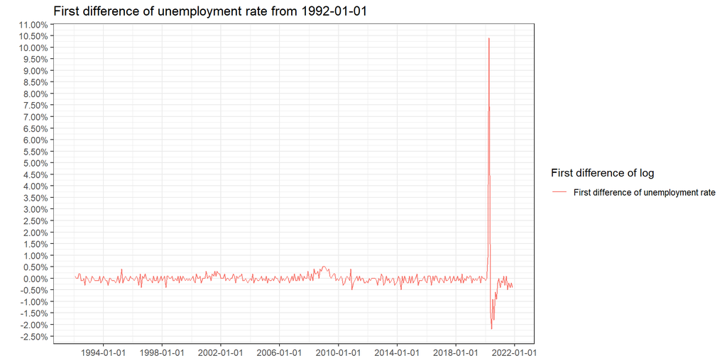

```r
ggplot(data=NULL,aes(x=final_ts_df$Date[-1]))+
  geom_line(aes(y=diff(final_ts_df$Unemployment_Rate),color="First difference of unemployment rate"))+ggtitle("First difference of unemployment rate from 1992-01-01")+theme_bw()+xlab(NULL)+scale_x_date(date_breaks="4 year")+
  scale_y_continuous(labels=scales::percent,breaks=scales::pretty_breaks(n=20))+labs(colour="First difference of log")+ylab("")
```

## Checking for stationarity and persistence of first difference:

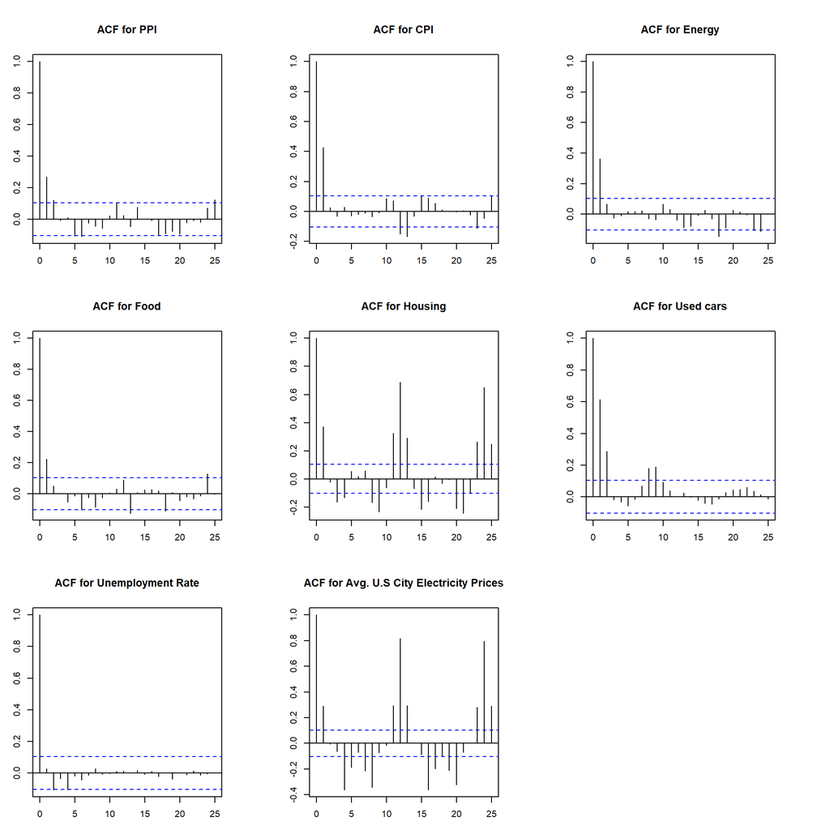

```r
par(mar = c(3,3,5,5))
par(mfrow=c(3,3))
acf(diff(log(final_ts_df$PPI)),main="ACF for PPI")
acf(diff(log(final_ts_df$CPI)),main="ACF for CPI")
acf(diff(log(final_ts_df$Energy)),main="ACF for Energy")
acf(diff(log(final_ts_df$Food)),main="ACF for Food")
acf(diff(log(final_ts_df$Housing_prices)),main="ACF for Housing")
acf(diff(log(final_ts_df$Used_cars)),main="ACF for Used cars")
acf(diff(final_ts_df$Unemployment_Rate),main="ACF for Unemployment Rate")
acf(diff(log(final_ts_df$AvgElectricityPrices)),main="ACF for Avg. U.S City Electricity Prices")
```

## Lag importance examination:

We want to run a regression of PPI and CPI against our response variables, but we also want to know if we should include any lags of our variables in the regressors as well. To do so, we choose to: 1. Run a regression of our variables with the lags with statistically significant autocorrelation from the ACF against CPI and PPI.. 2. Use a model F-test to determine if a model without lags could fit as well as a model with lags.

Food and Energy

```r
final_ts_df['log_Energy']=log(final_ts_df$Energy)
final_ts_df['diff_log_Energy']=difference(final_ts_df$log_Energy)
final_ts_df['lag_diff_log_Energy']=lag(final_ts_df$diff_log_Energy)
final_ts_df['log_Food']=log(final_ts_df$Food)
final_ts_df['diff_log_Food']=difference(final_ts_df$log_Food)
final_ts_df['lag_diff_log_Food']=lag(final_ts_df$diff_log_Food)
final_ts_df['log_CPI']=log(final_ts_df$CPI)
final_ts_df['diff_log_CPI']=difference(final_ts_df$log_CPI)
final_ts_df['log_PPI']=log(final_ts_df$PPI)
final_ts_df['diff_log_PPI']=difference(final_ts_df$log_PPI)
```

Housing and Used Cars

```r
final_ts_df['log_Housing'] = log(final_ts_df$Housing_prices)
final_ts_df['diff_log_Housing'] = difference(final_ts_df$log_Housing)
final_ts_df['lag_12_diff_log_Housing'] = lag(final_ts_df$diff_log_Housing, k = 12)
final_ts_df['log_Used_Cars'] = log(final_ts_df$Used_cars)
final_ts_df['diff_log_Used_Cars'] = difference(final_ts_df$log_Used_Cars)
final_ts_df['lag_diff_log_Used_Cars'] = lag(final_ts_df$diff_log_Used_Cars)
```

Electricity and Unemployment

```r
final_ts_df['diff_Unemployment']=difference(final_ts_df$Unemployment_Rate)
final_ts_df['lag_diff_Unemployment'] = lag(final_ts_df['diff_Unemployment'])
final_ts_df['log_AvgElectricityPrices']=log(final_ts_df$AvgElectricityPrices)
final_ts_df['diff_log_AvgElectricityPrices']=difference(final_ts_df$log_AvgElectricityPrices)
final_ts_df['lag_4_diff_log_AvgElectricityPrices'] = lag(final_ts_df$diff_log_AvgElectricityPrices, k = 4)
```

Model Building and Coefficient Evaluation Using p-value of 0.05 above (coefficient will be starred) For CPI

```r
lag_CPI_Energy=lm(diff_log_CPI~diff_log_Energy+lag_diff_log_Energy,data=final_ts_df)
lag_CPI_Food=lm(diff_log_CPI~diff_log_Food+lag_diff_log_Food,data=final_ts_df)
lag_CPI_Housing=lm(diff_log_CPI~diff_log_Housing + lag_12_diff_log_Housing,data=final_ts_df)
lag_CPI_Used_Cars=lm(diff_log_CPI~diff_log_Used_Cars + lag_diff_log_Used_Cars,data=final_ts_df)
lag_CPI_Unemployment=lm(diff_log_CPI~diff_Unemployment + lag_diff_Unemployment,data=final_ts_df)
lag_CPI_AvgElectricityPrices=lm(diff_log_CPI~diff_log_AvgElectricityPrices + lag_4_diff_log_AvgElectricityPrices, data = final_ts_df)
cpi_models=list(
  "Energy"=lag_CPI_Energy,
  "Food"=lag_CPI_Food,
  "Housing"=lag_CPI_Housing,
  "Used_cars"=lag_CPI_Used_Cars,
  "Unemployment"=lag_CPI_Unemployment,
  "Average Electricity Prices"=lag_CPI_AvgElectricityPrices
)
modelsummary(cpi_models,estimate="{estimate}{stars}")
```

|  | Energy | Food | Housing | Used_cars | Unemployment | Average Electricity Prices |
| --- | --- | --- | --- | --- | --- | --- |
| (Intercept) | 0.002*** | 0.002*** | 0.001*** | 0.002*** | 0.002*** | 0.002*** |
|  | (0.000) | (0.000) | (0.000) | (0.000) | (0.000) | (0.000) |
| diff_log_Energy | 0.016*** |  |  |  |  |  |
|  | (0.001) |  |  |  |  |  |
| lag_diff_log_Energy | 0.016*** |  |  |  |  |  |
|  | (0.001) |  |  |  |  |  |
| diff_log_Food |  | 0.014** |  |  |  |  |
|  |  | (0.005) |  |  |  |  |
| lag_diff_log_Food |  | 0.024*** |  |  |  |  |
|  |  | (0.005) |  |  |  |  |
| diff_log_Housing |  |  | 0.317*** |  |  |  |
|  |  |  | (0.055) |  |  |  |
| lag_12_diff_log_Housing |  |  | 0.100+ |  |  |  |
|  |  |  | (0.055) |  |  |  |
| diff_log_Used_Cars |  |  |  | 0.049*** |  |  |
|  |  |  |  | (0.014) |  |  |
| lag_diff_log_Used_Cars |  |  |  | 0.004 |  |  |
|  |  |  |  | (0.014) |  |  |
| diff_Unemployment |  |  |  |  | -0.091*** |  |
|  |  |  |  |  | (0.023) |  |
| lag_diff_Unemployment |  |  |  |  | -0.045+ |  |
|  |  |  |  |  | (0.023) |  |
| diff_log_AvgElectricityPrices |  |  |  |  |  | 0.011 |
|  |  |  |  |  |  | (0.007) |
| lag_4_diff_log_AvgElectricityPrices |  |  |  |  |  | 0.013+ |
|  |  |  |  |  |  | (0.007) |
| Num.Obs. | 357 | 357 | 357 | 357 | 357 | 357 |
| R2 | 0.503 | 0.114 | 0.128 | 0.060 | 0.054 | 0.024 |
| R2 Adj. | 0.500 | 0.109 | 0.123 | 0.054 | 0.049 | 0.019 |
| AIC | -3465.2 | -3259.0 | -3264.4 | -3237.6 | -3235.6 | -3224.4 |
| BIC | -3449.7 | -3243.5 | -3248.9 | -3222.1 | -3220.1 | -3208.9 |
| Log.Lik. | 1736.620 | 1633.490 | 1636.193 | 1622.804 | 1621.815 | 1616.189 |
| F | 179.114 | 22.835 | 25.884 | 11.222 | 10.183 | 4.376 |

For CPI, we determine that Energy and Food are significant up to their first lags based on their coefficients.

Model Building - PPI For PPI

```r
lag_PPI_Energy=lm(diff_log_PPI~diff_log_Energy+lag_diff_log_Energy,data=final_ts_df)
lag_PPI_Food=lm(diff_log_PPI~diff_log_Food+lag_diff_log_Food,data=final_ts_df)
lag_PPI_Housing=lm(diff_log_PPI~diff_log_Housing + lag_12_diff_log_Housing,data=final_ts_df)
lag_PPI_Used_Cars=lm(diff_log_PPI~diff_log_Used_Cars + lag_diff_log_Used_Cars,data=final_ts_df)
lag_PPI_Unemployment=lm(diff_log_PPI~diff_Unemployment + lag_diff_Unemployment,data=final_ts_df)
lag_PPI_AvgElectricityPrices=lm(diff_log_PPI~diff_log_AvgElectricityPrices + lag_4_diff_log_AvgElectricityPrices, data = final_ts_df)
ppi_models=list(
  "Energy"=lag_PPI_Energy,
  "Food"=lag_PPI_Food,
  "Housing"=lag_PPI_Housing,
  "Used_cars"=lag_PPI_Used_Cars,
  "Unemployment"=lag_PPI_Unemployment,
  "Average Electricity Prices"=lag_PPI_AvgElectricityPrices
)
modelsummary(ppi_models,estimate="{estimate}{stars}")
```

|  | Energy | Food | Housing | Used_cars | Unemployment | Average Electricity Prices |
| --- | --- | --- | --- | --- | --- | --- |
| (Intercept) | 0.001*** | 0.002*** | -0.001 | 0.002*** | 0.002*** | 0.002*** |
|  | (0.000) | (0.000) | (0.001) | (0.000) | (0.000) | (0.000) |
| diff_log_Energy | 0.080*** |  |  |  |  |  |
|  | (0.005) |  |  |  |  |  |
| lag_diff_log_Energy | 0.027*** |  |  |  |  |  |
|  | (0.005) |  |  |  |  |  |
| diff_log_Food |  | 0.082*** |  |  |  |  |
|  |  | (0.016) |  |  |  |  |
| lag_diff_log_Food |  | 0.094*** |  |  |  |  |
|  |  | (0.016) |  |  |  |  |
| diff_log_Housing |  |  | 1.284*** |  |  |  |
|  |  |  | (0.195) |  |  |  |
| lag_12_diff_log_Housing |  |  | -0.011 |  |  |  |
|  |  |  | (0.195) |  |  |  |
| diff_log_Used_Cars |  |  |  | 0.073 |  |  |
|  |  |  |  | (0.050) |  |  |
| lag_diff_log_Used_Cars |  |  |  | 0.028 |  |  |
|  |  |  |  | (0.050) |  |  |
| diff_Unemployment |  |  |  |  | -0.458*** |  |
|  |  |  |  |  | (0.078) |  |
| lag_diff_Unemployment |  |  |  |  | 0.223** |  |
|  |  |  |  |  | (0.078) |  |
| diff_log_AvgElectricityPrices |  |  |  |  |  | 0.062** |
|  |  |  |  |  |  | (0.024) |
| lag_4_diff_log_AvgElectricityPrices |  |  |  |  |  | 0.035 |
|  |  |  |  |  |  | (0.024) |
| Num.Obs. | 357 | 357 | 357 | 357 | 357 | 357 |
| R2 | 0.514 | 0.189 | 0.124 | 0.016 | 0.105 | 0.033 |
| R2 Adj. | 0.511 | 0.185 | 0.119 | 0.010 | 0.100 | 0.027 |
| AIC | -2568.9 | -2386.5 | -2358.9 | -2317.2 | -2351.1 | -2323.5 |
| BIC | -2553.4 | -2371.0 | -2343.4 | -2301.7 | -2335.6 | -2308.0 |
| Log.Lik. | 1288.447 | 1197.264 | 1183.469 | 1162.613 | 1179.563 | 1165.749 |
| F | 186.899 | 41.339 | 25.100 | 2.815 | 20.727 | 6.002 |

For PPI, we determine that Energy and Food are significant up to their first lags based on their coefficients. Additioanlly, unemployment rate is also significant for PPI up to the first lag.

## At this point, I will go ahead and insert Intervention term for COVID starting MARCH 2020

```r
# Something like this but for COVID
COVID <- c(seq(0, 0, length.out = 338), seq(1, 1, length.out = 21))
final_ts_df['COVID']=as.data.frame(COVID)
```

I will rerun the models having removed observations with NAs so that my model selection functions later down below can work. This will ultimately only remove 2 rows.

```r
# Here I will set the new final_ts_df object to only include non-NA having rows
final_ts_df <- final_ts_df[c(-1,-2),]
```

## Final model

We fit a model using all six variables with no lags, and the same model but including the first lags for Energy and Food Price as determined above.

### For CPI

```r
complete_fit_CPI <- lm( diff_log_CPI ~ diff_log_Energy  + diff_log_Food + diff_log_Housing +   diff_log_Used_Cars + diff_Unemployment + diff_log_AvgElectricityPrices, data = final_ts_df)
# We insert the first lag for Food and Energy as determined above.
complete_lag_fit_CPI <- lm( diff_log_CPI ~ diff_log_Energy + lag_diff_log_Energy + diff_log_Food + lag_diff_log_Food + diff_log_Housing  +  diff_log_Used_Cars +  diff_Unemployment + diff_log_AvgElectricityPrices, data = final_ts_df)
```

```r
cpi_full_models=list(CPI_full=complete_fit_CPI,
     CPI_full_w_lags=complete_lag_fit_CPI)
modelsummary(cpi_full_models,estimate="{estimate}{stars}")
```

|  | CPI_full | CPI_full_w_lags |
| --- | --- | --- |
| (Intercept) | 0.001*** | 0.001*** |
|  | (0.000) | (0.000) |
| diff_log_Energy | 0.018*** | 0.014*** |
|  | (0.002) | (0.001) |
| diff_log_Food | 0.005 | 0.004 |
|  | (0.004) | (0.003) |
| diff_log_Housing | 0.319*** | 0.254*** |
|  | (0.053) | (0.047) |
| diff_log_Used_Cars | 0.037*** | 0.033*** |
|  | (0.008) | (0.007) |
| diff_Unemployment | -0.003 | 0.040* |
|  | (0.019) | (0.017) |
| diff_log_AvgElectricityPrices | -0.012+ | -0.011+ |
|  | (0.006) | (0.006) |
| lag_diff_log_Energy |  | 0.015*** |
|  |  | (0.001) |
| lag_diff_log_Food |  | 0.005 |
|  |  | (0.003) |
| Num.Obs. | 357 | 357 |
| R2 | 0.446 | 0.581 |
| R2 Adj. | 0.436 | 0.571 |
| AIC | -3418.3 | -3514.3 |
| BIC | -3387.3 | -3475.5 |
| Log.Lik. | 1717.152 | 1767.130 |
| F | 46.903 | 60.334 |

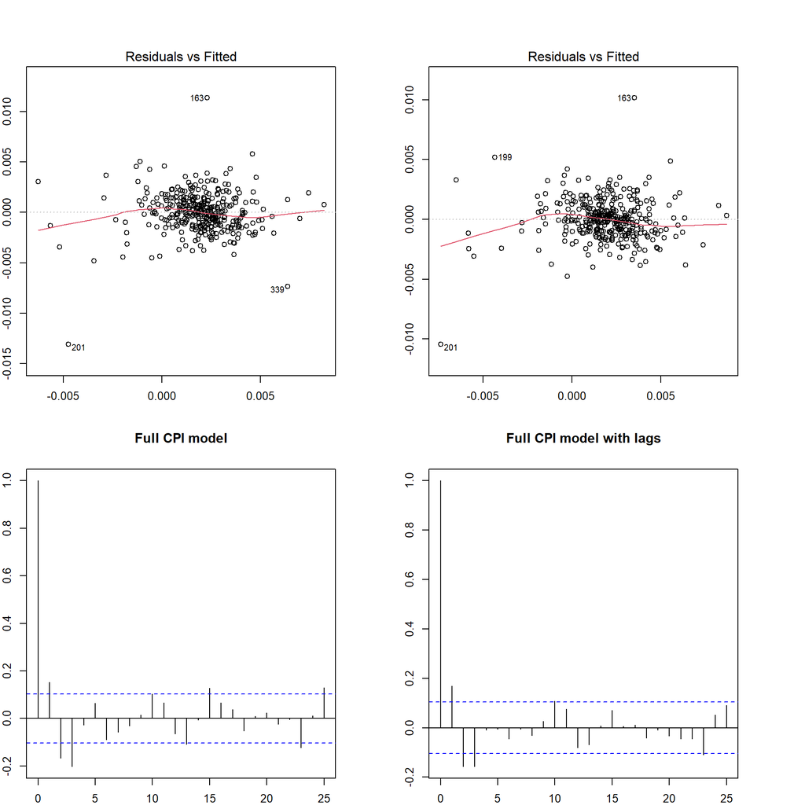

```r
par(mar = c(2,2,5,5))
par(mfrow=c(2,2))
plot(complete_fit_CPI,which=c(1))
plot(complete_lag_fit_CPI,which=c(1))
acf(complete_fit_CPI$residuals,main="Full CPI model")
acf(complete_lag_fit_CPI$residuals,main="Full CPI model with lags")
```

## For CPI w/ COVID Included

```r
COVID_complete_fit_CPI <- lm( diff_log_CPI ~ diff_log_Energy  + diff_log_Food + diff_log_Housing +   diff_log_Used_Cars + diff_Unemployment + diff_log_AvgElectricityPrices + factor(COVID), data = final_ts_df)

COVID_complete_lag_fit_CPI <- lm( diff_log_CPI ~ diff_log_Energy + lag_diff_log_Energy + diff_log_Food + lag_diff_log_Food + diff_log_Housing  +  diff_log_Used_Cars +  diff_Unemployment + lag_diff_Unemployment + diff_log_AvgElectricityPrices + factor(COVID), data = final_ts_df)
```

```r
covid_cpi_models=list(
  "cpi_covid"=COVID_complete_fit_CPI,
  "cpi_covid_lag"=COVID_complete_lag_fit_CPI
)
modelsummary(covid_cpi_models,estimate="{estimate}{stars}")
```

|  | cpi_covid | cpi_covid_lag |
| --- | --- | --- |
| (Intercept) | 0.001*** | 0.001*** |
|  | (0.000) | (0.000) |
| diff_log_Energy | 0.018*** | 0.014*** |
|  | (0.002) | (0.002) |
| diff_log_Food | 0.005 | 0.004 |
|  | (0.004) | (0.003) |
| diff_log_Housing | 0.320*** | 0.255*** |
|  | (0.053) | (0.047) |
| diff_log_Used_Cars | 0.038*** | 0.036*** |
|  | (0.009) | (0.008) |
| diff_Unemployment | -0.002 | 0.042* |
|  | (0.019) | (0.017) |
| diff_log_AvgElectricityPrices | -0.012+ | -0.011* |
|  | (0.006) | (0.006) |
| factor(COVID)1 | 0.000 | -0.001 |
|  | (0.000) | (0.000) |
| lag_diff_log_Energy |  | 0.015*** |
|  |  | (0.002) |
| lag_diff_log_Food |  | 0.005 |
|  |  | (0.003) |
| lag_diff_Unemployment |  | 0.006 |
|  |  | (0.017) |
| Num.Obs. | 357 | 357 |
| R2 | 0.446 | 0.583 |
| R2 Adj. | 0.435 | 0.571 |
| AIC | -3416.5 | -3511.9 |
| BIC | -3381.6 | -3465.3 |
| Log.Lik. | 1717.264 | 1767.930 |
| F | 40.144 | 48.360 |

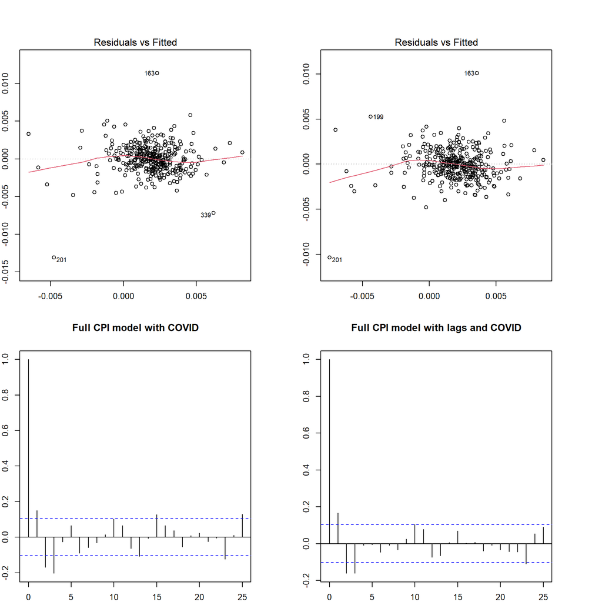

```r
par(mar = c(2,2,5,5))
par(mfrow=c(2,2))
plot(COVID_complete_fit_CPI,which=c(1))
plot(COVID_complete_lag_fit_CPI,which=c(1))
acf(COVID_complete_fit_CPI$residuals,main="Full CPI model with COVID")
acf(COVID_complete_lag_fit_CPI$residuals,main="Full CPI model with lags and COVID")
```

COVID doesn’t seem to play a significant role for CPI model.

### For PPI

```r
complete_fit_PPI <- lm( diff_log_PPI ~ diff_log_Energy  + diff_log_Food + diff_log_Housing +   diff_log_Used_Cars + diff_Unemployment + diff_log_AvgElectricityPrices, data = final_ts_df)

complete_lag_fit_PPI <- lm( diff_log_PPI ~ diff_log_Energy + lag_diff_log_Energy + diff_log_Food + lag_diff_log_Food + diff_log_Housing  +  diff_log_Used_Cars +  diff_Unemployment + diff_log_AvgElectricityPrices, data = final_ts_df)
```

```r
ppi_models=list(
  "ppi"=complete_fit_PPI,
  "ppi_lag"=complete_lag_fit_PPI
)
modelsummary(ppi_models,estimate="{estimate}{stars}")
```

|  | ppi | ppi_lag |
| --- | --- | --- |
| (Intercept) | 0.000 | 0.000 |
|  | (0.000) | (0.000) |
| diff_log_Energy | 0.075*** | 0.069*** |
|  | (0.005) | (0.005) |
| diff_log_Food | 0.047*** | 0.039*** |
|  | (0.012) | (0.012) |
| diff_log_Housing | 0.878*** | 0.709*** |
|  | (0.170) | (0.166) |
| diff_log_Used_Cars | 0.025 | 0.019 |
|  | (0.027) | (0.026) |
| diff_Unemployment | -0.096 | -0.041 |
|  | (0.059) | (0.059) |
| diff_log_AvgElectricityPrices | 0.000 | 0.004 |
|  | (0.020) | (0.020) |
| lag_diff_log_Energy |  | 0.019*** |
|  |  | (0.005) |
| lag_diff_log_Food |  | 0.040*** |
|  |  | (0.012) |
| Num.Obs. | 357 | 357 |
| R2 | 0.555 | 0.592 |
| R2 Adj. | 0.547 | 0.583 |
| AIC | -2592.5 | -2619.7 |
| BIC | -2561.4 | -2580.9 |
| Log.Lik. | 1304.232 | 1319.833 |
| F | 72.685 | 63.125 |

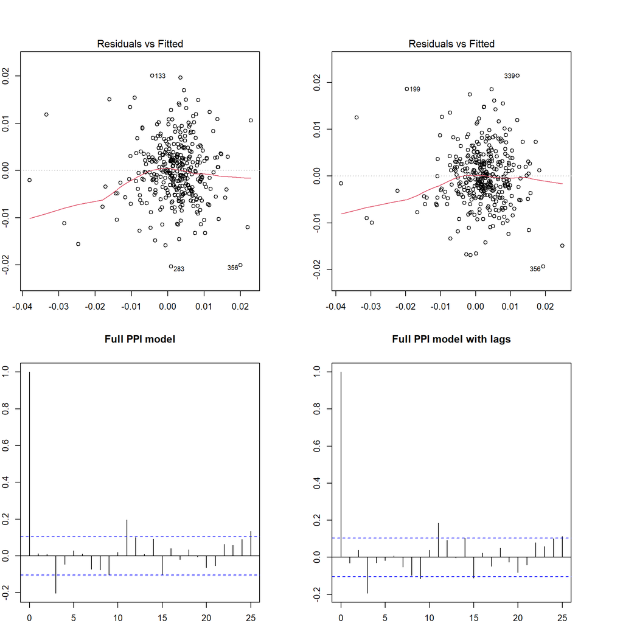

```r
par(mar = c(2,2,5,5))
par(mfrow=c(2,2))
plot(complete_fit_PPI,which=c(1))
plot(complete_lag_fit_PPI,which=c(1))
acf(complete_fit_PPI$residuals,main="Full PPI model")
acf(complete_lag_fit_PPI$residuals,main="Full PPI model with lags")
```

```r
vif(complete_lag_fit_CPI)
```

```
##               diff_log_Energy           lag_diff_log_Energy
##                      1.349102                      1.312173
##                 diff_log_Food             lag_diff_log_Food
##                      1.135771                      1.178699
##              diff_log_Housing            diff_log_Used_Cars
##                      1.777652                      1.022949
##             diff_Unemployment diff_log_AvgElectricityPrices
##                      1.207648                      1.678175
```

```r
vif(complete_lag_fit_PPI)
```

```
##               diff_log_Energy           lag_diff_log_Energy
##                      1.349102                      1.312173
##                 diff_log_Food             lag_diff_log_Food
##                      1.135771                      1.178699
##              diff_log_Housing            diff_log_Used_Cars
##                      1.777652                      1.022949
##             diff_Unemployment diff_log_AvgElectricityPrices
##                      1.207648                      1.678175
```

## For PPI w/ COVID Included

```r
COVID_complete_fit_PPI <- lm( diff_log_PPI ~ diff_log_Energy  + diff_log_Food + diff_log_Housing +   diff_log_Used_Cars + diff_Unemployment + diff_log_AvgElectricityPrices + factor(COVID), data = final_ts_df)

COVID_complete_lag_fit_PPI <- lm( diff_log_PPI ~ diff_log_Energy + lag_diff_log_Energy + diff_log_Food + lag_diff_log_Food + diff_log_Housing  +  diff_log_Used_Cars +  diff_Unemployment + diff_log_AvgElectricityPrices + factor(COVID), data = final_ts_df)
```

```r
covid_ppi_models=list(
  "ppi_covid"=COVID_complete_fit_PPI,
  "ppi_covid_lag"=COVID_complete_lag_fit_PPI
)
modelsummary(covid_ppi_models,estimate="{estimate}{stars}")
```

|  | ppi_covid | ppi_covid_lag |
| --- | --- | --- |
| (Intercept) | 0.000 | 0.000 |
|  | (0.000) | (0.000) |
| diff_log_Energy | 0.075*** | 0.069*** |
|  | (0.005) | (0.005) |
| diff_log_Food | 0.047*** | 0.039*** |
|  | (0.012) | (0.012) |
| diff_log_Housing | 0.879*** | 0.710*** |
|  | (0.170) | (0.166) |
| diff_log_Used_Cars | 0.026 | 0.023 |
|  | (0.028) | (0.027) |
| diff_Unemployment | -0.096 | -0.039 |
|  | (0.059) | (0.059) |
| diff_log_AvgElectricityPrices | 0.000 | 0.004 |
|  | (0.020) | (0.020) |
| factor(COVID)1 | 0.000 | -0.001 |
|  | (0.002) | (0.001) |
| lag_diff_log_Energy |  | 0.019*** |
|  |  | (0.005) |
| lag_diff_log_Food |  | 0.040*** |
|  |  | (0.012) |
| Num.Obs. | 357 | 357 |
| R2 | 0.555 | 0.592 |
| R2 Adj. | 0.546 | 0.582 |
| AIC | -2590.5 | -2617.9 |
| BIC | -2555.6 | -2575.2 |
| Log.Lik. | 1304.237 | 1319.934 |
| F | 62.126 | 56.004 |

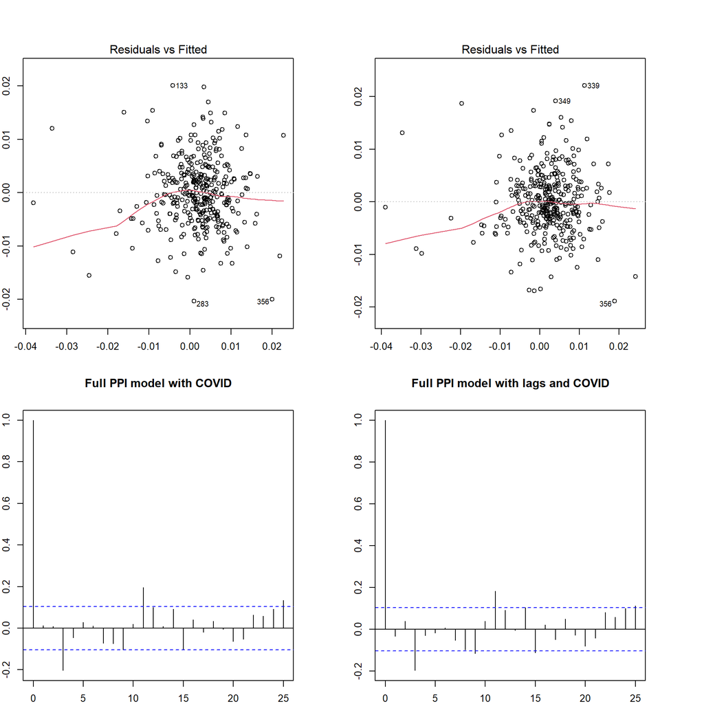

```r
par(mar = c(2,2,5,5))
par(mfrow=c(2,2))
plot(COVID_complete_fit_PPI,which=c(1))
plot(COVID_complete_lag_fit_PPI,which=c(1))
acf(COVID_complete_fit_PPI$residuals,main="Full PPI model with COVID")
acf(COVID_complete_lag_fit_PPI$residuals,main="Full PPI model with lags and COVID")
```

COVID does not play significant role in PPI model either.

## Model Selection based on leaps() & stepAIC()

Since including COVID in the CPI or PPI model does not produce statistically significant coefficient estimates, I will go ahead and only evaluate the complete models without the COVID intervention term.

The Leaps below is based on Mallow’s Cp which measures predictive ability of a fitted model. Good models have a small Mallow’s Cp value and a value close to the number of predictor variables in the model

### CPI Model Selection

```r
# Just included models commented out for my own purposes.

# complete_fit_CPI <- lm( diff_log_CPI ~ diff_log_Energy  + diff_log_Food + diff_log_Housing +   diff_log_Used_Cars + diff_Unemployment + diff_log_AvgElectricityPrices, data = final_ts_df)
#
# complete_lag_fit_CPI <- lm( diff_log_CPI ~ diff_log_Energy + lag_diff_log_Energy + diff_log_Food + lag_diff_log_Food + diff_log_Housing  +  diff_log_Used_Cars +  diff_Unemployment + lag_diff_Unemployment + diff_log_AvgElectricityPrices, data = final_ts_df)

complete_CPI.leaps.cp <- leaps(y = final_ts_df$diff_log_CPI, x = final_ts_df[,c(11,14,21,24,26,29)], method = c("Cp"))
complete_CPI.full.cp <- cbind(complete_CPI.leaps.cp$which, complete_CPI.leaps.cp$Cp)
complete_CPI.full.cp
```

```
##   1 2 3 4 5 6
## 1 1 0 0 0 0 0  58.737460
## 1 0 0 1 0 0 0 203.014989
## 1 0 0 0 1 0 0 240.903286
## 1 0 1 0 0 0 0 249.134460
## 1 0 0 0 0 1 0 250.580997
## 1 0 0 0 0 0 1 269.314265
## 2 1 0 1 0 0 0  23.346530
## 2 1 0 0 1 0 0  42.015714
## 2 1 0 0 0 0 1  54.765497
## 2 1 1 0 0 0 0  59.153125
## 2 1 0 0 0 1 0  60.636907
## 2 0 0 1 1 0 0 170.636083
## 2 0 1 1 0 0 0 176.808096
## 2 0 0 1 0 1 0 181.986515
```

[output cut: 29 more lines]

Seems like Mallow’s Cp values will differ slightly every time that the function runs, but values will lead to the same conclusions outlined below and thereafter.

From the results above, the model that produces a Mallow’s Cp closest to the number of predictor variables in the complete_CPI model (6) is the model(1 0 1 1 1 1 6.664595) that excludes diff_log_food. However, going with the model that minimizes Mallow’s Cp (1 0 1 1 0 1 4.686577) excludes diff_log_food & diff_Unemployment, which were both insignificant in the complete_fit_CPI model. So maybe we should see what a complete model without these predictor variables would look like? I’ll go ahead and explore that later down below.

```r
complete_lag_CPI.leaps.cp <- leaps(y = final_ts_df$diff_log_CPI, x = final_ts_df[,c(11, 12, 14, 15, 21, 24,26, 27, 29)], method = c("Cp"))
complete_lag_CPI.full.cp <- cbind(complete_lag_CPI.leaps.cp$which, complete_lag_CPI.leaps.cp$Cp)
complete_lag_CPI.full.cp
```

```
##   1 2 3 4 5 6 7 8 9
## 1 1 0 0 0 0 0 0 0 0 187.195110
## 1 0 1 0 0 0 0 0 0 0 195.581557
## 1 0 0 0 0 1 0 0 0 0 376.485673
## 1 0 0 0 1 0 0 0 0 0 399.891562
## 1 0 0 0 0 0 1 0 0 0 426.194710
## 1 0 0 1 0 0 0 0 0 0 436.993922
## 1 0 0 0 0 0 0 1 0 0 438.891763
## 1 0 0 0 0 0 0 0 0 1 463.469609
## 1 0 0 0 0 0 0 0 1 0 465.885652
## 2 1 1 0 0 0 0 0 0 0  60.748821
## 2 1 0 0 0 1 0 0 0 0 140.138613
## 2 0 1 0 0 1 0 0 0 0 147.350507
## 2 1 0 0 1 0 0 0 0 0 162.611728
## 2 1 0 0 0 0 1 0 0 0 164.632381
```

[output cut: 65 more lines]

Now down below, I will go ahead and run the same function but the metric will now be Adjusted R-Squared, so we ultimately want to choose a model based on the LARGEST Adjusted R-Squared (this selection will only really be valid if we’re working off the basis that the OLS assumptions are justified btw).

```r
complete_CPI.leaps.r <- leaps(y = final_ts_df$diff_log_CPI, x = final_ts_df[,c(11,14,21,24,26,29)], method = c("adjr2"))
complete_CPI.full.r <- cbind(complete_CPI.leaps.r$which, complete_CPI.leaps.r$adjr2)
complete_CPI.full.r
```

```
##   1 2 3 4 5 6
## 1 1 0 0 0 0 0 0.34608029
## 1 0 0 1 0 0 0 0.11693932
## 1 0 0 0 1 0 0 0.05676529
## 1 0 1 0 0 0 0 0.04369257
## 1 0 0 0 0 1 0 0.04139519
## 1 0 0 0 0 0 1 0.01164309
## 2 1 0 1 0 0 0 0.40378493
## 2 1 0 0 1 0 0 0.37405085
## 2 1 0 0 0 0 1 0.35374450
## 2 1 1 0 0 0 0 0.34675640
## 2 1 0 0 0 1 0 0.34439321
## 2 0 0 1 1 0 0 0.16919947
## 2 0 1 1 0 0 0 0.15936942
## 2 0 0 1 0 1 0 0.15112184
```

[output cut: 29 more lines]

So it seems that from the complete_fit_CPI model, based on getting the maximum Adjusted R-Squared value, the best model to go with is (1 1 1 1 0 1 0.43868042) which is the model that excludes diff_Unemployment.

```r
complete_lag_CPI.leaps.r <- leaps(y = final_ts_df$diff_log_CPI, x = final_ts_df[,c(11, 12, 14, 15, 21, 24,26, 27, 29)], method = c("adjr2"))
complete_lag_CPI.full.r <- cbind(complete_lag_CPI.leaps.r$which, complete_lag_CPI.leaps.r$adjr2)
complete_lag_CPI.full.r
```

```
##   1 2 3 4 5 6 7 8 9
## 1 1 0 0 0 0 0 0 0 0 0.34608029
## 1 0 1 0 0 0 0 0 0 0 0.33592829
## 1 0 0 0 0 1 0 0 0 0 0.11693932
## 1 0 0 0 1 0 0 0 0 0 0.08860591
## 1 0 0 0 0 0 1 0 0 0 0.05676529
## 1 0 0 1 0 0 0 0 0 0 0.04369257
## 1 0 0 0 0 0 0 1 0 0 0.04139519
## 1 0 0 0 0 0 0 0 0 1 0.01164309
## 1 0 0 0 0 0 0 0 1 0 0.00871841
## 2 1 1 0 0 0 0 0 0 0 0.50015974
## 2 1 0 0 0 1 0 0 0 0 0.40378493
## 2 0 1 0 0 1 0 0 0 0 0.39503009
## 2 1 0 0 1 0 0 0 0 0 0.37650381
## 2 1 0 0 0 0 1 0 0 0 0.37405085
```

[output cut: 65 more lines]

From the complete_lag_fit_CPI, the model that achieves the largest adjusted R-squared value would be (1 1 1 1 1 1 1 0 1 0.573446674) which exludes lag_diff_unemployment.

Now below I will go ahead and run the stepAIC() function on both CPI models to look at how a backtrace from the full model affects the AIC and then look at which models produce the best AIC.

```r
stepAIC(complete_fit_CPI, direction = "backward")
```

```
## Start:  AIC=-4433.43
## diff_log_CPI ~ diff_log_Energy + diff_log_Food + diff_log_Housing +
##     diff_log_Used_Cars + diff_Unemployment + diff_log_AvgElectricityPrices
##
##                                 Df  Sum of Sq       RSS     AIC
## - diff_Unemployment              1 0.00000008 0.0013879 -4435.4
## - diff_log_Food                  1 0.00000724 0.0013950 -4433.6
## <none>                                        0.0013878 -4433.4
## - diff_log_AvgElectricityPrices  1 0.00001473 0.0014025 -4431.7
## - diff_log_Used_Cars             1 0.00007581 0.0014636 -4416.4
## - diff_log_Housing               1 0.00014196 0.0015298 -4400.7
## - diff_log_Energy                1 0.00049021 0.0018780 -4327.4
##
## Step:  AIC=-4435.41
## diff_log_CPI ~ diff_log_Energy + diff_log_Food + diff_log_Housing +
##     diff_log_Used_Cars + diff_log_AvgElectricityPrices
##
##                                 Df  Sum of Sq       RSS     AIC
## - diff_log_Food                  1 0.00000729 0.0013952 -4435.5
## <none>                                        0.0013879 -4435.4
## - diff_log_AvgElectricityPrices  1 0.00001473 0.0014026 -4433.6
## - diff_log_Used_Cars             1 0.00007610 0.0014640 -4418.3
## - diff_log_Housing               1 0.00014195 0.0015298 -4402.6
## - diff_log_Energy                1 0.00054505 0.0019329 -4319.1
##
## Step:  AIC=-4435.53
## diff_log_CPI ~ diff_log_Energy + diff_log_Housing + diff_log_Used_Cars +
##     diff_log_AvgElectricityPrices
##
##                                 Df  Sum of Sq       RSS     AIC
## <none>                                        0.0013952 -4435.5
## - diff_log_AvgElectricityPrices  1 0.00001668 0.0014118 -4433.3
## - diff_log_Used_Cars             1 0.00007621 0.0014714 -4418.5
## - diff_log_Housing               1 0.00014338 0.0015386 -4402.6
## - diff_log_Energy                1 0.00062852 0.0020237 -4304.8
```

```
##
## Call:
## lm(formula = diff_log_CPI ~ diff_log_Energy + diff_log_Housing +
##     diff_log_Used_Cars + diff_log_AvgElectricityPrices, data = final_ts_df)
##
## Coefficients:
##                   (Intercept)                diff_log_Energy
##                      0.001144                       0.018943
##              diff_log_Housing             diff_log_Used_Cars
##                      0.320676                       0.037120
## diff_log_AvgElectricityPrices
##                     -0.013048
```

```r
stepAIC(complete_lag_fit_CPI, direction = "backward")
```

```
## Start:  AIC=-4529.38
## diff_log_CPI ~ diff_log_Energy + lag_diff_log_Energy + diff_log_Food +
##     lag_diff_log_Food + diff_log_Housing + diff_log_Used_Cars +
##     diff_Unemployment + diff_log_AvgElectricityPrices
##
##                                 Df  Sum of Sq       RSS     AIC
## - diff_log_Food                  1 3.8470e-06 0.0010527 -4530.1
## - lag_diff_log_Food              1 5.7420e-06 0.0010546 -4529.4
## <none>                                        0.0010489 -4529.4
## - diff_log_AvgElectricityPrices  1 1.1494e-05 0.0010604 -4527.5
## - diff_Unemployment              1 1.7215e-05 0.0010661 -4525.6
## - diff_log_Used_Cars             1 6.0364e-05 0.0011092 -4511.4
## - diff_log_Housing               1 8.6538e-05 0.0011354 -4503.1
## - diff_log_Energy                1 2.8611e-04 0.0013350 -4445.3
## - lag_diff_log_Energy            1 3.0010e-04 0.0013490 -4441.6
##
## Step:  AIC=-4530.08
## diff_log_CPI ~ diff_log_Energy + lag_diff_log_Energy + lag_diff_log_Food +
##     diff_log_Housing + diff_log_Used_Cars + diff_Unemployment +
##     diff_log_AvgElectricityPrices
##
##                                 Df  Sum of Sq       RSS     AIC
## <none>                                        0.0010527 -4530.1
## - lag_diff_log_Food              1 0.00000783 0.0010605 -4529.4
## - diff_log_AvgElectricityPrices  1 0.00001263 0.0010654 -4527.8
## - diff_Unemployment              1 0.00001669 0.0010694 -4526.5
## - diff_log_Used_Cars             1 0.00006042 0.0011132 -4512.2
## - diff_log_Housing               1 0.00008622 0.0011389 -4504.0
## - lag_diff_log_Energy            1 0.00029858 0.0013513 -4442.9
## - diff_log_Energy                1 0.00031780 0.0013705 -4437.9
```

```
##
## Call:
## lm(formula = diff_log_CPI ~ diff_log_Energy + lag_diff_log_Energy +
##     lag_diff_log_Food + diff_log_Housing + diff_log_Used_Cars +
##     diff_Unemployment + diff_log_AvgElectricityPrices, data = final_ts_df)
##
## Coefficients:
##                   (Intercept)                diff_log_Energy
##                      0.001230                       0.014801
##           lag_diff_log_Energy              lag_diff_log_Food
##                      0.014523                       0.005317
##              diff_log_Housing             diff_log_Used_Cars
##                      0.253322                       0.033121
##             diff_Unemployment  diff_log_AvgElectricityPrices
##                      0.039333                      -0.011368
```